# **R** illustrations for the note *On the sub-Gaussianity of the Beta and Dirichlet distributions* by Olivier Marchal and Julyan Arbel

This file provides **R** code for the note *On the sub-Gaussianity of the Beta and Dirichlet distributions* by Olivier Marchal and Julyan Arbel. The focus is to obtain the optimal proxy variance of Beta distributions $X$, that is the smallest $\sigma^2$ such that:
$$\mathbb{E}[\exp(\lambda (X-\mathbb{E}[X]))]\le\exp\left(\frac{\lambda^2\sigma^2}{2}\right)\,\,\text{for all } \lambda\in\mathbb{R}.$$

# 1 Names of R functions

We consider the optimal proxy variance, denoted by $\sigma^2_{\text{opt}}$, of a Beta$(\alpha,\beta)$ distribution. It is given by the function $\verb|var_proxy_opt(alpha,beta)|$ while $\verb|variance_beta(alpha,beta)|$ provides the variance
$$\text{Var}[X]=\frac{\alpha\beta}{(\alpha+\beta)^2(\alpha+\beta+1)}.$$

The code is as follows:

```r
alpha = 1
beta = 1.3
var_proxy_opt(alpha,beta)
```

```
## [1] 0.075551
```

```r
variance_beta(alpha,beta)
```

```
## [1] 0.07446869
```

# 2 Curves for the optimal proxy variance

Let $S = \alpha+\beta$ be fixed and let vary $\alpha$ and $\beta$ as $S-\alpha$.

- Simple upper bound $\sigma_0^2$ for the proxy variance: dotted black line,
- Optimal proxy variance $\sigma_{\text{opt}}^2$: magenta line,
- Variance $\text{Var}[X]$: dashed green line.

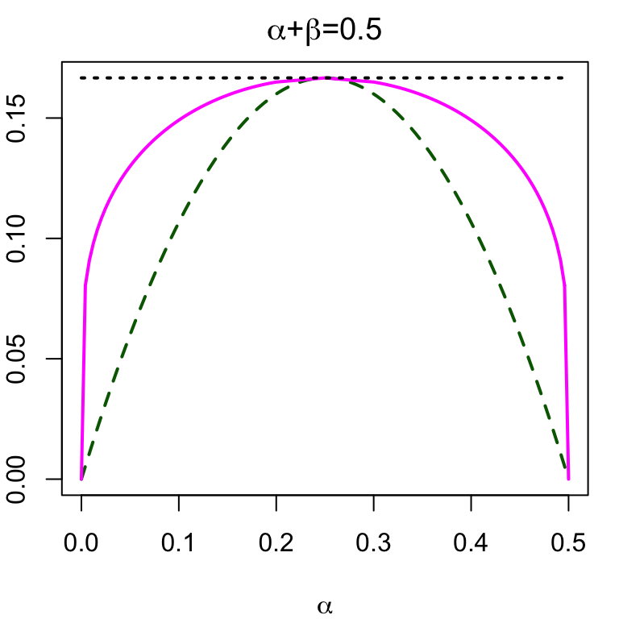

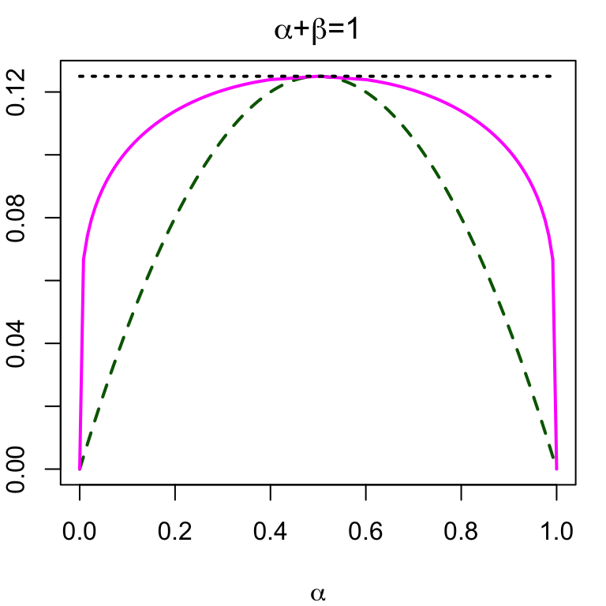

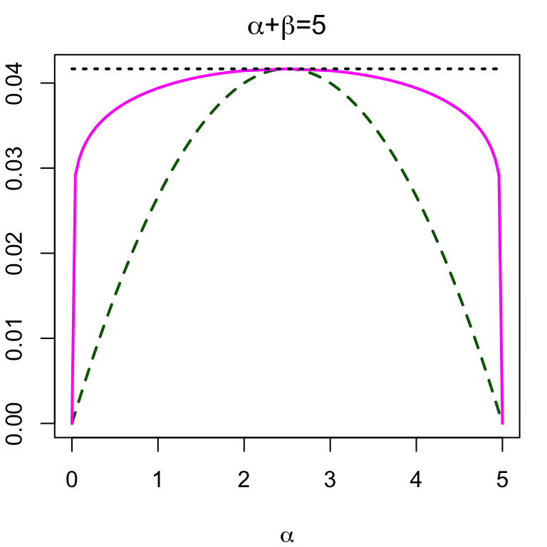

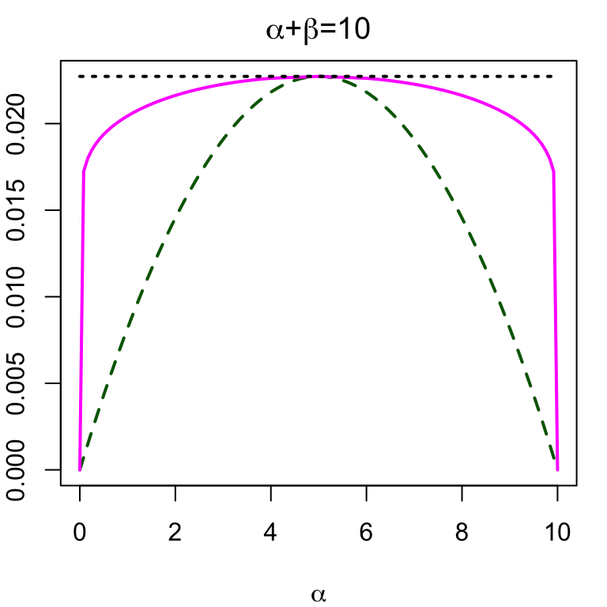

# 3 Surface for the optimal proxy variance

We now let both $\alpha$ and $\beta$ vary.

- Simple upper bound $\sigma_0^2$ for the proxy variance: not shown (is a ruled surface),
- Optimal proxy variance $\sigma_{\text{opt}}^2$: magenta surface,
- Variance $\text{Var}[X]$: green surface.

The graphs can be zoomed in/out and rotated with the mouse.

[interactive chart not shown]

3D view of optimal proxy variance (magenta) and variance (green). Should be possible to play with the mouse on graphs: zoom in/out, rotate, etc.

[interactive chart not shown]

# 4 Illustration of the proof

The intuition of the proof can be seen from this figure which represents the difference
$$\lambda\mapsto\exp\left(\mathbb{E}[X]\lambda+\frac{\sigma^2}{2}\lambda^2\right)-\mathbb{E}[\exp(\lambda X)],$$
for various values of $\sigma^2$. The main argument is that the optimal proxy variance is obtained for that curve (in magenta) whose positive local minimum equals zero.

- For $t=0$ (simple upper bound $\sigma_0^2$), the curve [dotted black] remains strictly positive.
- For $t=t_{\text{opt}}$ (optimal proxy variance $\sigma^2_{\text{opt}}$), the curve [magenta] has zero minimum (at $x_0$).
- For $t=1$ (leading to the variance), the curve [dashed green] has zero derivative at $x=0$, hence is directly negative after 0.
- The intermediate case with $t_{\text{non opt}}$ in the interval $(t_{\text{opt}},1)$ produces a curve [orange, dash and dots] which is first positive, then negative, and positive again.

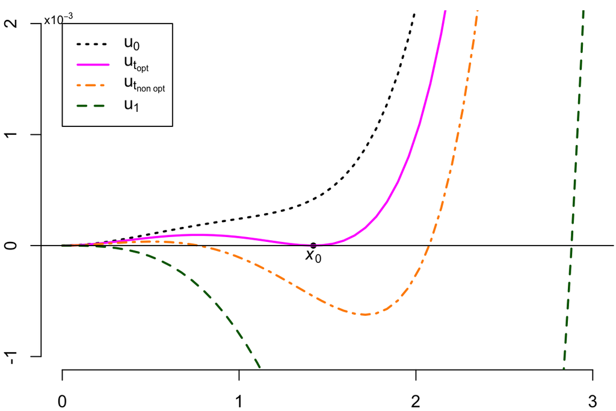